# 12.1 Features, functions, and nonlinear regression

#### Example 5. Modeling population growth using a parameterized feature transformation

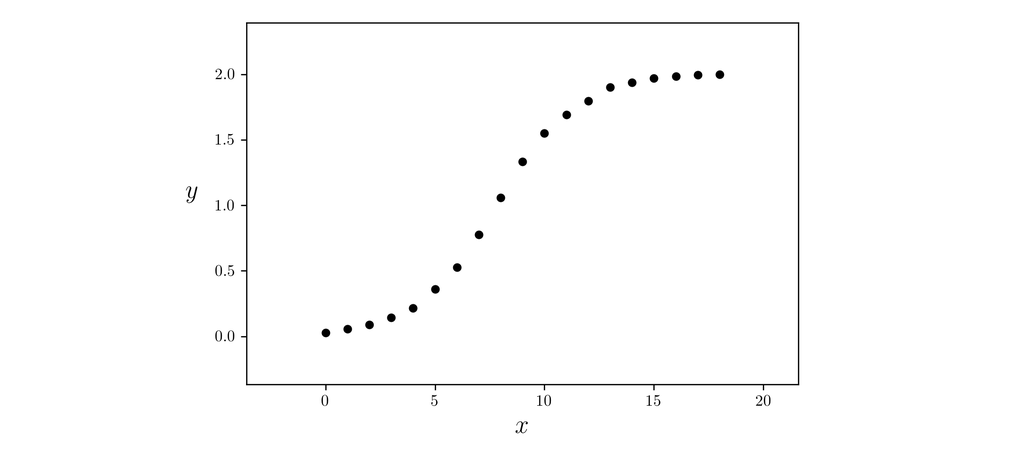

```python
## This code cell will not be shown in the HTML version of this notebook
# load data
csvname = datapath + 'yeast.csv'
data = np.loadtxt(csvname,delimiter = ',')

# get input/output pairs
x = data[:,:-1].T
y = data[:,-1:]

# plot dataset
demo = regress_plotter.Visualizer(data)
demo.plot_data()
```

- use a *parameterized* tanh feature transformation

\begin{equation} f\left(x\right) = \text{tanh}\left(w_0 + w_1x\right). \end{equation}

- then our `model` a linear combination of this nonlinear feature transformation as

\begin{equation} \text{model}\left(x,\mathbf{w}_{\!}\right) = w_2 + w_{3\,}f\left(x\right). \end{equation}

```python
# our nonlinearity, known as a feature transformation
def feature_transforms(x,w):
    # tack a 1 onto the top of each input point all at once
    o = np.ones((1,np.shape(x)[1]))
    x = np.vstack((o,x))

    # calculate feature transform
    f = np.tanh(np.dot(x.T,w)).T
    return f
```

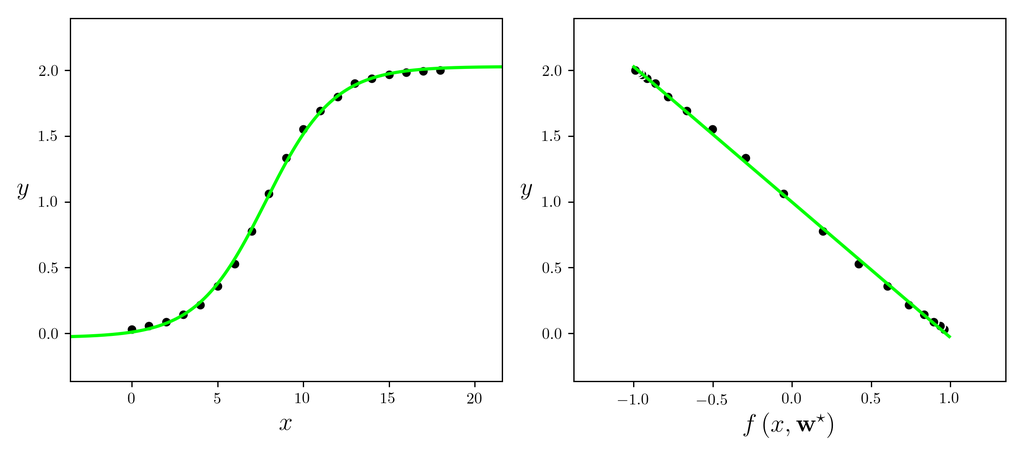

```python
## This code cell will not be shown in the HTML version of this notebook
# plot data and fit in original and feature transformed space
ind = np.argmin(run1.cost_history)
w_best = run1.weight_history[ind]
demo.plot_fit_and_feature_space(w_best,run1.model,run1.feature_transforms,normalizer = run1.normalizer)
```

#### Example 6. Using an unparameterized feature transformation to model a classic physics dataset

- famous Galileo experiment to understand the pull of gravity

[figure not shown]

- repeatedly rolling a metal ball down a grooved $\frac{1}{2}$ meter long piece of wood set at an incline Galileo timed how long the ball took to get $\frac{1}{4}$,$\frac{1}{2}$, $\frac{2}{3}$, $\frac{3}{4}$, and all the way down the wood ramp.
- data from a modern reenactment

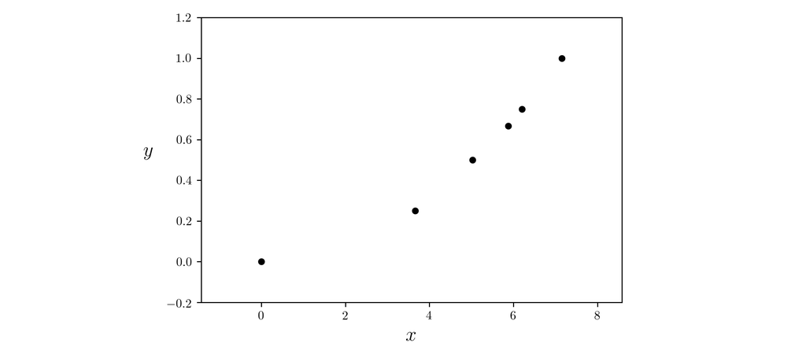

```python
## This code cell will not be shown in the HTML version of this notebook
# load data
csvname = datapath + 'galileo_ramp_data.csv'
data = np.loadtxt(csvname,delimiter = ',')

# get input/output pairs
x = data[:,:-1].T
y = data[:,-1:]

# plot dataset
demo = regress_plotter.Visualizer(data)
demo.plot_data()
```

- and using his physical intuition Galileo - intuited a *quadratic* relationship
- in ML/DL jargon that for some $w_0$, $w_1$, and $w_2$ the modeling function

\begin{equation} \text{model}(x,\mathbf{w}) = w_0 + w_1x + w_2x^2 \end{equation}

- here we have **two** feature transformations: $f_1(x) = x$ and the quadratic term $f_2(x) = x^2$,
- build them into the same `feature_transforms` function

```python
def feature_transforms(x):
    # calculate feature transform
    f = np.array([(x.flatten()**d) for d in range(1,3)])
    return f
```

- minimize Least Squares cost via gradient descent using this

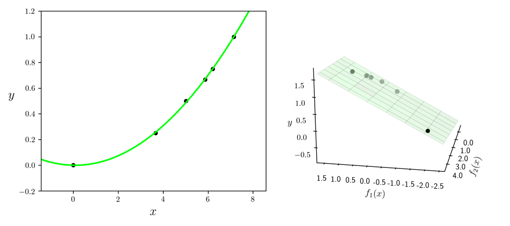

```python
# plot data and fit in original and feature transformed space
ind = np.argmin(run1.cost_history)
w_best = run1.weight_history[ind]
demo.plot_fit_and_feature_space(w_best,run1.model,run1.feature_transforms,normalizer = run1.normalizer,view = [25,100])
```